# Echocardiography Analysis

Mark E. Pepin

3/09/2021

This script contains the coding needed to import, clean, visualize, and analyze echocardiographic data.

## 0.1 Clean raw data from Echocardiography tracings.

The reports (.csv) generated from the Echo software produces a poorly-formatted sheet of information that needs to be parsed to extract phenotypic parameters. This function looks within all sub-directories for the echo reports (“.csv”), and compiles them. Once compiled, this table is exported as “**Master_Table.xlsx**” in the same directory where the script is run.

## 0.2 Import Metadata for Mice

This next step is specific for a given project, and requires information about each mouse (genotype, sex, treatment, etc..). **This must meet the following parameters:**

1. It must be created using an **"_Index.xlsx**" ending and placed in the same folder location where this script is run.
2. It must contain a “Sample_ID” column where each mouse identifier is located. NOTE: this must be identical to the identifiers used to label mice within the Echo reports.
3. **“Duration”** (this is derived from “**Int_Date**” (Date of the intervention) and “**Study_Date**” (Date of Echo)

```
##   Sample_ID Sex   DOB Genotype Intervention     Group Int_Date   DOD FDG.1
## 1       312   F 43866     BAP1         ORAB BAP1_ORAB    44251 44274     x
## 2       313   F 43866     BAP1         ORAB BAP1_ORAB    44251    NA     x
## 3       316   M 43866     BAP1         ORAB BAP1_ORAB    44251    NA     x
## 4       348   M 43867     BAP1         ORAB BAP1_ORAB    44252    NA     x
## 5       349   M 43867     BAP1         ORAB BAP1_ORAB    44252    NA     x
## 6       382   F 43868     BAP1         ORAB BAP1_ORAB    44251    NA     x
##   FDG.2 FDG.3
## 1    NA    NA
## 2    NA    NA
## 3    NA    NA
## 4    NA    NA
## 5    NA    NA
## 6    NA    NA
```

## 0.3 Time-Course Study

It is often useful to see phenotypic changes with respect to time. For this reason, a scatter plot can be generated that plots these changes for each experimental group. To run this code, you must have a column entitled “**Group**” which contains the groups you wish to compare.

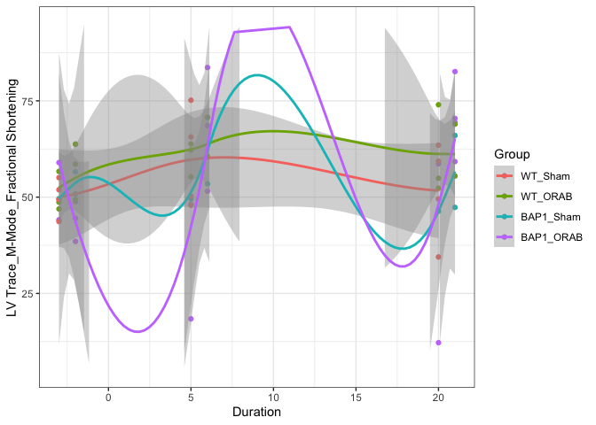

# 1 Group-wise comparison

In addition to time-course studies, it can be helpful to compute statistical comparison between experimental groups at each time-point. The following script accomplishes this by iteratively performing pairwise statistics with respect to the “**WT-Sham**” value in the “**Group**” Column.

```
## [1] FALSE
```

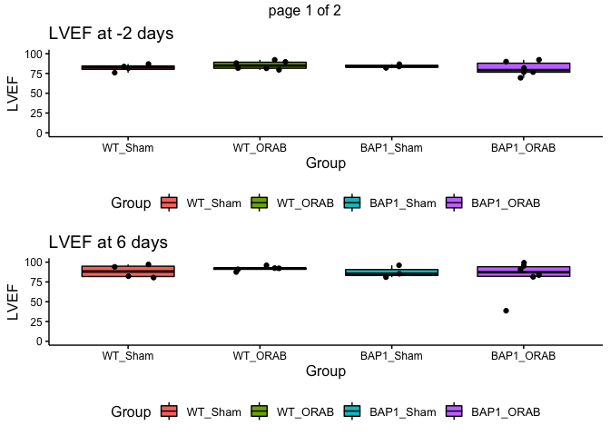

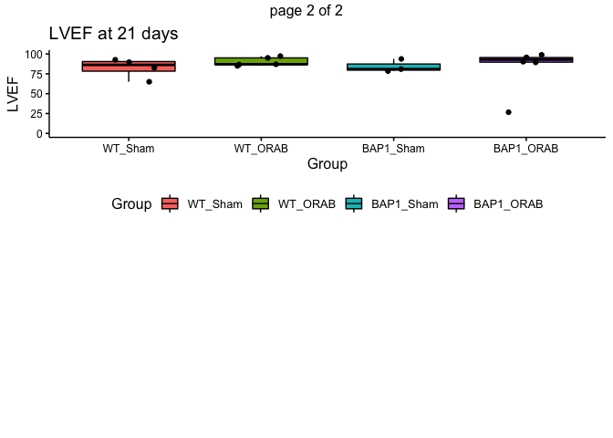

# 2 Survival Plots

```
## Welcome to the RTCGA (version: 1.20.0).
```

[figure not shown]

[figure not shown]

# 3 **Script References**

```
## Time difference of 10.99999 secs
```

```
##  setting  value
##  version  R version 4.0.4 (2021-02-15)
##  os       macOS Big Sur 10.16
##  system   x86_64, darwin17.0
##  ui       X11
##  language (EN)
##  collate  en_US.UTF-8
##  ctype    en_US.UTF-8
##  tz       Europe/Berlin
##  date     2021-04-01
```